개요ToolUniverse · 논문 발표

## ToolUniverse

PAPER REVIEW · 10 MIN

# ToolUniverse

AI Scientist를 위한  
**과학 도구 통합 플랫폼**

새로운 신약개발 모델이 아니라, 기존 과학 도구를 찾고 호출하며 연구 과정에 연결하는 공통 인프라

Harvard Medical School · Zitnik 연구팀arXiv:2509.23426 · 2026 v3 기준

[figure not shown]

Notion 원고에 포함된 논문 그림

개요ToolUniverse · 논문 발표

## Tool · MCP · Skill, 무엇이 다른가?

“모두 MCP”가 아니라, 서로 다른 과학 기능을 같은 방식으로 호출하게 만드는 구조

2,700+

Scientific tools

130+

Research skills

Notion 원고의 2026년 8월 v3 기준 수치  
초기 논문 v1의 도구 개수와 혼용하지 않음

TOOL

실제로 실행되는 기능

ChEMBL 조회 · PubChem 검색 · ADMET 예측

MCP

에이전트와 연결하는 방식

ToolUniverse에 접근하는 여러 인터페이스 중 하나

SKILL

연구 작업 절차

어떤 tool을 어떤 순서와 검증 기준으로 사용할지 기술

핵심: **ToolUniverse = 과학용 도구의 통합 Wrapper + 검색·호출 기능 + 연구용 Skill**

구성 및 동작 방식ToolUniverse · 논문 발표

## 어떤 도구들이 들어 있나?

원고에서 분류한 13가지 도구 범주: 신약개발을 넘어 여러 과학 분야 지원

01

**논문·연구 자료**논문, 인용 관계, 데이터셋, 연구비

02

**질환·타깃**질환 관련 유전자·단백질과 작용 경로

03

**유전자·변이**DNA 서열, 변이와 질환의 관계

04

**발현·오믹스**조직·세포의 RNA·단백질·대사체

05

**단백질·구조**서열·입체 구조·상호작용·설계

06

**분자·약물 탐색**화학 구조, 활성 데이터, 후보 비교

07

**ADMET·안전성**약물 특성, 독성, 이상사례

08

**임상·의료**임상시험, 진료 지침, 진단 자료

09

**면역·감염**항체, 백신, 병원체, 미생물

10

**생태·생물종**생물종, 생물다양성, 계통 관계

11

**통계·계산**통계 검정, 이미지, 범용 ML

12

**기타 과학·공공 자료**물리·천문·환경·식품·공공통계

13

**설치·도구 운영**도구 검색·설치·공유·파일 처리

구성 및 동작 방식ToolUniverse · 논문 발표

## 왜 다시 한 번 감싸는가?

도구 자체의 성능보다, 서로 다른 도구를 재사용 가능하게 연결하는 것이 핵심

기존 방식

### 프로젝트별 별도 연결

신약개발 AI Agent

OpenTargets  
REST API

ChEMBL  
API

ADMET-AI  
Python / ML

각각의 API·인증·입력 형식에 맞게 직접 구현  
**bespoke: 프로젝트별 맞춤 연결**

→

ToolUniverse 방식

### 공통 호출 인터페이스

신약개발 AI Agent

ToolUniverse

OpenTargets

ChEMBL

ADMET-AI

API·Python·ML 모델을 같은 방식으로 검색·실행  
**연결 작업의 재사용성 개선**

왜 필요한가? **새 AI Scientist를 만들 때마다 반복되는 API Wrapper 개발을 줄이기 위해서**

구성 및 동작 방식ToolUniverse · 논문 발표

## 질문을 입력하면 어떻게 동작하나?

Skill을 참고한 에이전트가 등록된 도구를 찾아 실행하고, 반환된 근거를 해석

① USER

**연구 질문**

“BRAF가 좋은 치료 타깃인가?”

→

② AGENT

**연구 계획**

Skill 참고 · 필요한 근거 판단

→

③ ToolUniverse

**검색과 실행**

find_tools → execute_tool

→

④ TOOL

**정보 반환**

OpenTargets · ChEMBL · 모델

각 Tool의 공통 명세

`tool name``description``input schema``output schema``execution backend`

꼭 구분할 점

실제 데이터 조회·모델 실행은 **Tool**이 담당합니다. 다음에 무엇을 호출하고 결과를 어떻게 해석할지는 주로 **상위 LLM 에이전트**의 역할입니다.

MCP는 ToolUniverse에 접속하는 방법 중 하나입니다.

구성 및 동작 방식ToolUniverse · 논문 발표

## 6개 내부 모듈

일반 사용자는 기능을 직접 구현하지 않고, 필요한 도구나 에이전트를 연결해 활용

01

### Tool Manager

도구 등록·로딩·관리

평소 자동 활용

02

### Tool Finder

필요한 도구 검색

에이전트가 선택해 호출

03

### Tool Caller

입력 검사·도구 실행

실제 실행 담당

04

### Tool Composer

여러 호출을 연결해 workflow 구성

상위 agent와 함께 사용

05

### Tool Discoverer

새 도구 생성·발견 지원

필요할 때 활용

06

### Tool Optimizer

도구 설명·구성 개선

선택적 운영 기능

**모듈 6개 = 에이전트 6개가 아닙니다.** ToolUniverse에 구현된 소프트웨어 기능을 논문에서 모듈별로 설명한 것입니다.

특징ToolUniverse · 논문 발표

## 원고에서 강조한 세 가지 특징

Tool Discovery · 멀티에이전트 재사용 · 사용자 도구 확장

FEATURE 01

### 필요할 때 찾는 Tool Discovery

수천 개의 Tool schema를 LLM 문맥에 한 번에 넣지 않고, 소수의 검색 기능으로 필요한 Tool만 찾는 **compact mode**를 지원합니다.

2,700+등록 도구

→

Tool Finder

→

선택된 Tool실행

FEATURE 02

### 멀티에이전트에 재사용

Target Agent, Chemistry Agent, ADMET Agent가 같은 ToolUniverse 인프라를 공유할 수 있습니다.

TargetChemistryADMET

FEATURE 03

### 사용자 모델도 등록

직접 만든 QSAR predictor, molecule generator, docking model 등을 Tool로 감싸 연결할 수 있습니다.

QSARDockingGenerator

효과ToolUniverse · 논문 발표

## LAB-Bench 결과: 실제 문제 정답률 개선

원고의 논문 그래프를 그대로 사용했습니다. 지표는 신약개발 성공률이 아니라 생물학 QA 정답률입니다.

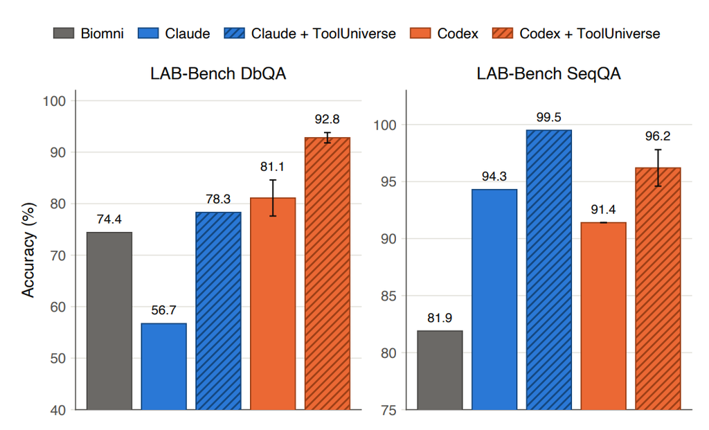

DbQA · Claude**+21.6%p***56.7 → 78.3*

DbQA · Codex**+11.7%p***81.1 → 92.8*

ToolUniverse 연결 전/후 정답률 비교  
원고에 포함된 논문 성능 그림

효과ToolUniverse · 논문 발표

## DbQA와 SeqQA는 무엇을 맞히는 시험인가?

벤치마크 해석을 위한 간단한 예시: 논문의 실제 시험 문항을 인용한 것은 아닙니다.

DbQA

### Database Question Answering

“데이터베이스에서 답을 정확하게 찾는가?”

예시 질문“특정 유전자가 인간의 몇 번 염색체에 있는가?”

정답 기준DB에 기록된 위치 정보를 올바르게 조회

SeqQA

### Sequence Question Answering

“DNA·RNA·단백질 서열을 올바르게 다루는가?”

예시 질문DNA `ATGCGC`의 GC 함량은?

정답 기준G/C 네 개 ÷ 전체 여섯 개 = **66.7%**

**해석 범위:** 생물학 정보 조회·서열 처리 능력을 평가합니다. 새로운 약물의 효능이나 실제 임상 성과를 검증한 시험은 아닙니다.

케이스 스터디 1ToolUniverse · 논문 발표

## 고콜레스테롤혈증 치료제 탐색

Gemini CLI + ToolUniverse: 후보물질 검색과 평가를 이어 붙인 사례

논문 초기 버전 v1연구 질문: Lovastatin보다 개선된 고콜레스테롤혈증 치료제 후보를 찾을 수 있을까?

1

치료 타깃 선정

문헌 검색 · 타깃 프로파일링 · 조직 발현

**HMG-CoA reductase** 선택

2

기존 약물 확인

DrugBank

**Lovastatin**을 개선 대상으로 선정

3

비슷한 화합물 검색

ChEMBL

기존 약물과 small molecule 후보 확보

4

결합력·약물 특성 예측

Boltz-2 · ADMET-AI

결합력과 BBB, 경구 생체이용률, 대사 안정성 평가

5

특허 검색

Patent-mining tools

상위 후보의 기존 특허·심혈관 용도 근거 확인

케이스 스터디 1ToolUniverse · 논문 발표

## 최종적으로 선정한 두 후보

이미 알려진 statin 1종 + 추가 연구할 수 있는 기존 화합물 1종

후보 01 · FDA 승인 약물

### Pravastatin

기존 스타틴 계열 약물을 다시 찾아냄

- Lovastatin보다 비표적 작용이 적은 약물로 평가
- 알려진 결과를 재현한 사례

기존 약물 재발견

후보 02 · ChEMBL 화합물

### CHEMBL2347006 / CHEMBL3970138

Lovastatin보다 우수한 특성이 **예측**된 화합물

- 더 높은 결합 친화도 예측
- 낮은 BBB 투과성, 양호한 경구 생체이용률·대사 안정성 예측
- 심혈관계 관련 특허 존재 확인

추가 검증이 필요한 후보

**주의:** 두 번째 화합물은 AI가 새로 생성한 분자가 아닙니다. 기존 DB/특허에 있던 화합물을 탐색했으며, 효능과 ADMET의 개선은 모델 예측입니다.

케이스 스터디 2ToolUniverse · 논문 발표

## BLM: 위험 신호와 치료 기회가 동시에 존재

원고의 1~3단계: 유전자 기능·병원성 변이 조사 → 암세포 의존성 확인

최신 v3 · Supplementary S9.1질문: BLM을 억제하면 특정 암을 치료할 수 있을까?

주의해야 할 유전학적 근거

### BLM 기능 상실은 암 위험 증가와 관련

464 질병 연관성

495 병원성 변이 검색

**OpenTargets · ClinVar · GeneBe**  
DNA 복구·유전체 유지 기능, Bloom syndrome 관련 근거 확인

특정 암에서 관찰된 취약성

### 일부 암세포는 BLM에 더 의존

94/1,258 의존성 높은 세포주

7.5% 전체 세포주 중

**DepMap CRISPR · OpenTargets**  
T/NK 종양, 피부 편평세포암 등 일부 맥락에서 의존성 확인

**핵심:** “암과 관련된 유전자”와 “암 치료에 억제할 만한 타깃”은 다릅니다. 정상세포 안전성과 암세포 선택성을 함께 봐야 합니다.

케이스 스터디 2ToolUniverse · 논문 발표

## BLM: 구조 정보와 기존 연구를 확인

원고의 4~5단계: 구조가 실제로 믿을 만한지, 비슷한 표적에 선례가 있는지 조사

원고의 4단계 · AlphaFold + PDBe

### 설계에 사용할 단백질 구조는?

**60.5**전체 AlphaFold 모델의 평균 pLDDT

단백질 전체 예측 구조의 일부 영역은 신뢰도가 제한적입니다.

7AUC · **1.53 Å**4CGZ4O3M

→ 고해상도 **실험 구조**를 구조 기반 설계의 출발점으로 사용

원고의 5단계 · Europe PMC

### 비슷한 표적의 연구 선례는?

**WRN**같은 RecQ helicase 계열

→

**MSI 암**선택적 의존성의 선례

WRN을 억제하는 항암제 연구·임상시험 사례를 확인했습니다.

→ BLM에서도 **암 유형·바이오마커를 특정한 실험**이 필요

케이스 스터디 2ToolUniverse · 논문 발표

## BLM 억제제 ML216의 한계

기존 probe의 약물 유사성과 안전성을 평가하고, 비슷한 화합물에도 위험 신호가 남는지 확인

원고의 6~7단계 · OpenTargets → PubChem → ADMET-AI → ChEMBL

### ML216: 약물처럼 보이지만 독성 경고

QED**0.66**약물 유사성

Lipinski**0**위반 개수

DILI**0.99**간 독성 예측 점수

hERG**0.56**심장 독성 관련 예측

ChEMBL 유사 화합물 검색

### 5개 유사체 재확인

0.987–0.992

유사도 72~78%인 화합물 5개에서도 DILI 예측값이 높게 유지

→ 단순 치환기 변경보다 **다른 scaffold** 검토

DILI 0.99는 “실제 간 손상이 99% 발생한다”는 의미가 아닌 **ML 모델의 예측 출력**입니다.

케이스 스터디 2ToolUniverse · 논문 발표

## BLM 사례의 결론은 “조건부 가능성”

타깃의 기회와 위험, 기존 화합물의 한계를 분리해 다음 실험 방향을 제시

TARGET

### BLM

특정 암에서 의존성 신호가 있지만, 정상세포 DNA 안정성 측면의 위험도 존재

**조건부 연구 가설**

+

COMPOUND

### ML216

약물 유사성은 있지만, 높은 DILI 예측 신호가 유사체에도 반복

**개발 가능한 lead로 보기 어려움**

**다음 연구 방향**

1 BLM에 의존하는 암 유형·바이오마커에서 효과 검증

2 정상세포·실험적 독성 데이터로 안전성 검증

3 필요하면 화학 구조(scaffold)를 바꾼 후보 탐색

케이스 스터디 3ToolUniverse · 논문 발표

## OXTR: 표적이 약물로 조절 가능하다는 것과 치료 효과는 별개

원고의 1~6단계: 구조·작용기전·결합력·기존 임상 근거를 각각 조사

최신 v3 · Supplementary S9.2질문: OXTR을 자폐 스펙트럼 장애의 CNS 치료제로 활용할 수 있을까?

01 · OpenTargets**수용체 기능**

OXTR은 GPCR. 관련 질병과 약물 정보를 조회

02 · AlphaFold + PDBe**구조 확인**

활성형 **7RYC** / 비활성형 **6TPK** 등 실험 구조 확보

03 · OpenTargets**기존 약물**

관련 약물 **9개** 확인. 주된 승인 용도는 생식·자궁 관련

04 · OpenTargets**작용기전**

Oxytocin = **agonist**, Atosiban = **antagonist**

05 · ChEMBL**실험 결합력**

OXTR 결합 친화도가 **Ki 3.2 nM**까지 보고됨

06 · Europe PMC**임상 문헌**

자폐 관련 임상 효능은 **일관되지 않음**. 해당 적응증 승인 약물 없음

케이스 스터디 3ToolUniverse · 논문 발표

## Nolasiban의 BBB 예측은 좋지만, 작용 방향이 반대

원고의 7단계: “BBB를 통과한다”는 예측만으로 재창출 후보라고 판단할 수 없습니다.

원래의 치료 가설

### 뇌에서 OXTR을 *활성화*해야 한다

Agonist · partial agonist · positive allosteric modulator 등이 후보 전략

OXTR**활성화 ↑**

≠

PubChem + ADMET-AI

### 찾아낸 Nolasiban은 *길항제*

QED**0.87**

BBB 예측**0.93**

OXTR**활성 억제 ↓**

→ 뇌에 도달할 수 있는 **OXTR agonist / PAM** 개발이 목표. Vasopressin 수용체 선택성과 실제 CNS 노출도 검증해야 합니다.

결론ToolUniverse · 논문 발표

## 결국 ToolUniverse의 기여는 어디에 있나?

“MCP보다 본질적으로 새로운 알고리즘인가?”보다는, 통합된 과학 도구 기반을 제공했다는 점

이 논문을 어떻게 평가할까?

새로운 신약개발 모델이 아니라  
기존 과학 도구를 재사용 가능하게 통합한 인프라

무엇을 구현했나**Wrapper + Tool Finder/Caller + Skills**

다른 API·Python·ML 모델을 공통 형식으로 제공

실제로 보여준 것**과학 QA 향상 · 후보 평가 흐름**

조회→예측→해석을 묶어 연구 가설을 정리

아직 증명하지 않은 것**새 약물의 실제 효능·안전성**

벤치마크는 QA, 케이스는 주로 in silico 검토

발표의 한 문장 결론: **ToolUniverse의 기여는 AI Scientist가 쓰는 과학 도구의 연결과 재사용을 쉽게 만든 소프트웨어 엔지니어링에 있다.**